# Lab 4 - `ggplot2` continued

STA 230

2023-09-04

# Lab

This lab will be a continuation of our exploration of `ggplot2`. Whereas the first lab was oriented around creating a number of standard plots from the data, here we will focus on a number of ancillary issues, including titles and labels, legends, and themes. The bulk of this lab will be focused on the topic of *scales*, which manage the relationship between the data and the resulting aesthetics. We will conclude by taking a closer look at some of the arguments that can be used to augment different layers.

## Titles and Axes

By default, plots made with `ggplot2` do not include a title, and the labels for the axes are taken from the variable names given in `aes()`. This is the case, for example, when we have our plot of engine displacement and highway miles

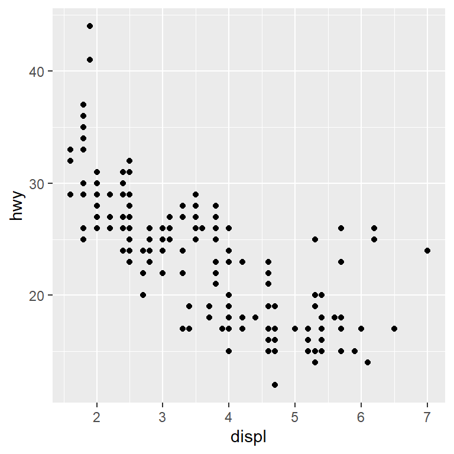

```r
library(ggplot2)

ggplot(mpg, aes(displ, hwy)) +
  geom_point()
```

We can add titles or change the x and y axis labels with the functions `ggtitle`, `xlab`, and `ylab`, respectively

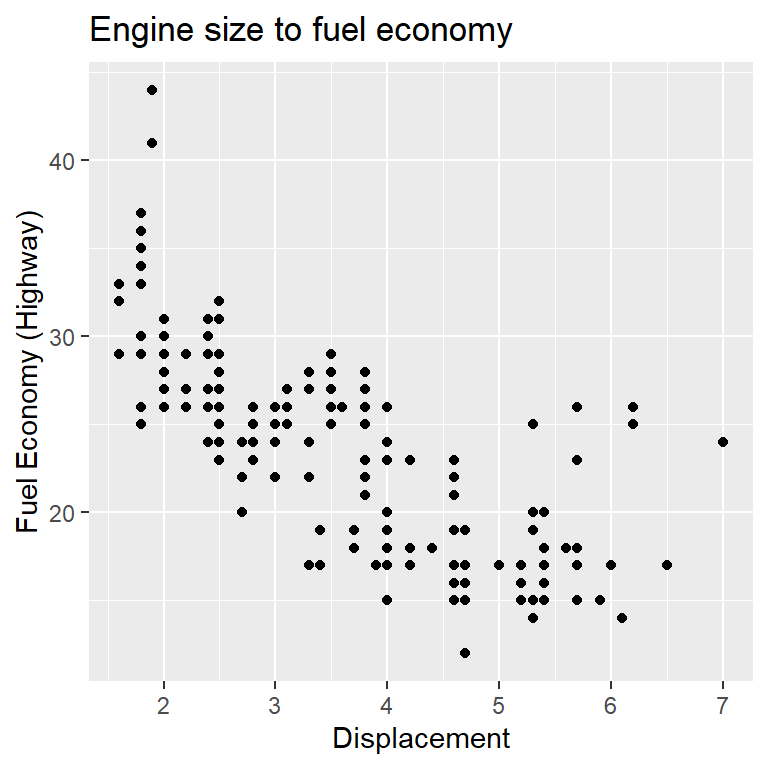

```r
library(ggplot2)

ggplot(mpg, aes(displ, hwy)) +
  geom_point() +
  ggtitle("Engine size to fuel economy") +
  xlab("Displacement") +
  ylab("Fuel Economy (Highway)")
```

As is typically the case with ggplots, there are multiple ways to accomplish the same goal. The `labs()` function allows us to modify multiple labels at once by specifying them with an argument

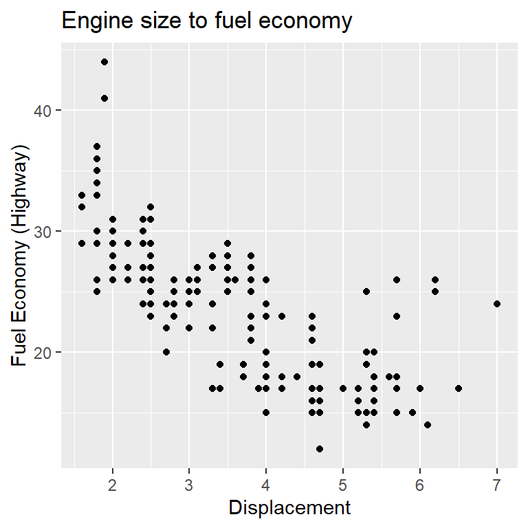

```r
ggplot(mpg, aes(displ, hwy)) +
  geom_point() +
  labs(x = "Displacement", y = "Fuel Economy (Highway)", title = "Engine size to fuel economy")
```

The `labs()` function also takes arguments for any grouping aesthetics. The argument name is the same as what is used for creating the groups, and changing these will make corresponding changes in the legend:

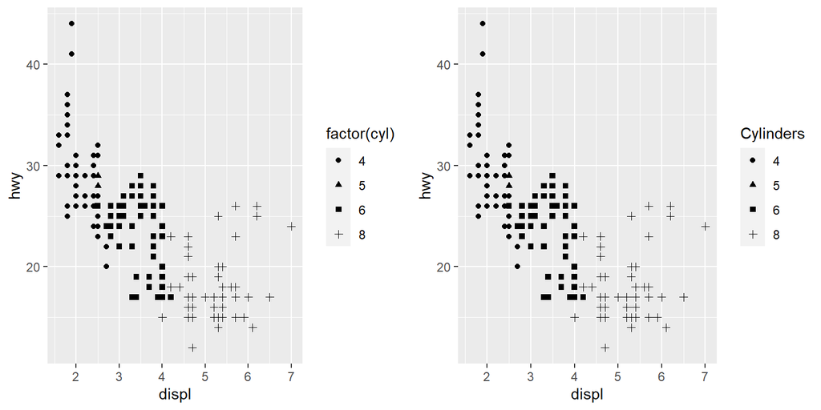

```r
## Without label
ggplot(mpg, aes(displ, hwy, shape = factor(cyl))) +
  geom_point()

## With label
ggplot(mpg, aes(displ, hwy, shape = factor(cyl))) +
  geom_point() +
  labs(shape = "Cylinders") # Since we used shape aesthetic, we use "shape" here
```

**Question 12** Using the `mpg` dataset, create a boxplot with `class` on the x-axis and `cty` on the y-axis. Add a color aesthetic that accounts for `year` (don’t forget to address the fact that, by default, `year` is a continuous variable). Create appropriate labels for the axes, title, and legend.

## Themes

As you might imagine, there are a tremendous variety of options to modify the style of your graphic. The collection of non-data related elements of your plot, including the appearance of titles, labels, legends, tick marks and lines all make up what is known as the *theme*. Elements related to the theme are modified with the `theme()` function; a quick look at `?theme` demonstrates how comprehensive this list can be. Here, however, we consider only a small subset of these items to demonstrate how the process works. It is less important that any of these are memorized; rather, knowing that such possibilties exist should assist you when using search engines to learn how to modify your graphics.

The system for modifying themes consists of two components:

1. The *elements* that are being modified (i.e., text, tick marks, legend)
2. The *element functions* associated with each element that control the visual properties.

For example, elements consisting of *text* are modified with the element function `element_text()`. We can also see some of the particulars that can be modified with `?element_text`. To motivate this, consider a plot that we constructed in the previous lab:

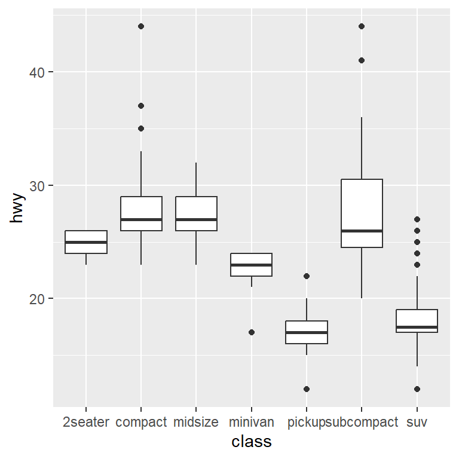

```r
ggplot(mpg, aes(class, hwy)) +
  geom_boxplot()
```

Because of the width of our figure, all of the labels on the x-axis are bunched together. We can help fix this problem by rotating the axis text on the x-axis. That is, we are modifying the element `axis.text.x` (that is, text that is located on the x-axis) with the element function `element_text`

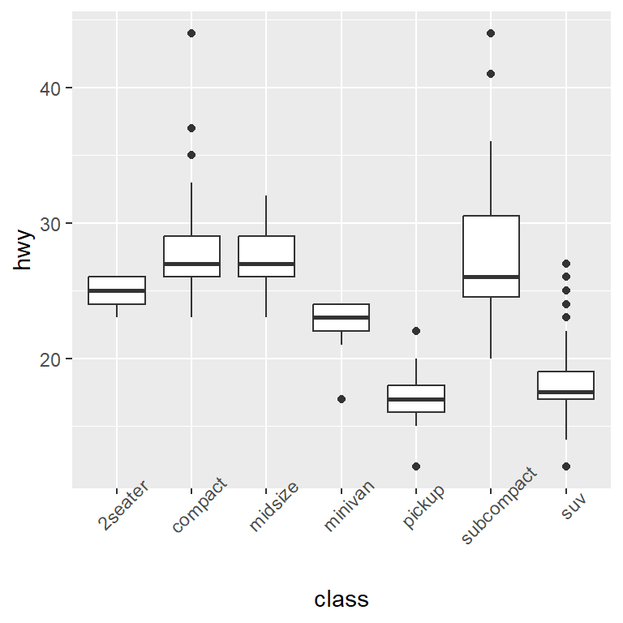

```r
ggplot(mpg, aes(class, hwy)) +
  geom_boxplot() +
  theme(axis.text.x = element_text(angle = 45))
```

Here, we see that the rotation has helped with the overlapping, but now the text is running into our plot. We can further alter the **V** erticle ad **JUST** ment with `vjust`

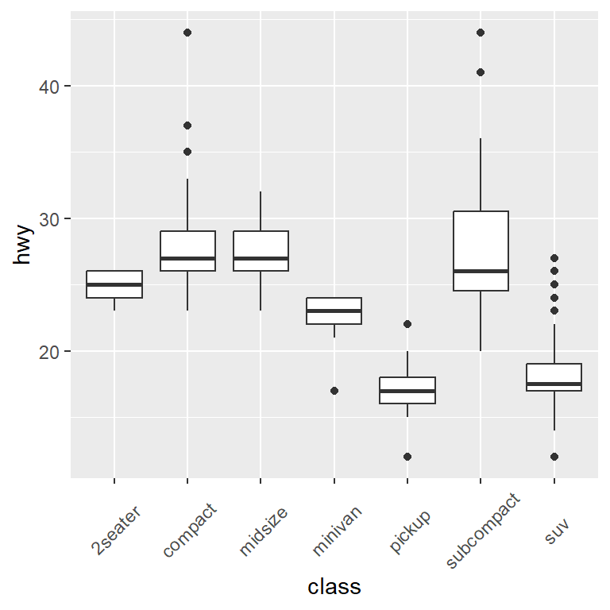

```r
ggplot(mpg, aes(class, hwy)) +
  geom_boxplot() +
  theme(axis.text.x = element_text(angle = 45, vjust = 0.5))
```

Note: considering a real-world example, it is highly unlikely that you would recall that text on the x-axis is specified with `axis.text.x`. However, if you had a general idea of what it is you wanted to change, it *is likely* that looking through the arguments of `?theme` that you would find something matching what you were looking for. This combined with with diligent search engine use is a potent strategy for solving most ggproblems.

**Question 13** For this question, use the code in the block below. To the plot that is generated, modify the following:

1. Modify the `plot.title` by changing its color to red and writing it in italics.
2. Change the size of the title and the text in the legend (two separate things) so that they are much bigger than the default

```r
ggplot(mpg, aes(displ, hwy, color = factor(cyl))) +
  geom_point()
```

### Pre-built themes

There are a number of pre-built themes that come included in ggplot, serving as a template from which you can further tailor your graphics. Here, for example, we consider a black and white theme, generated by adding `theme_bw()` to our constructed plot:

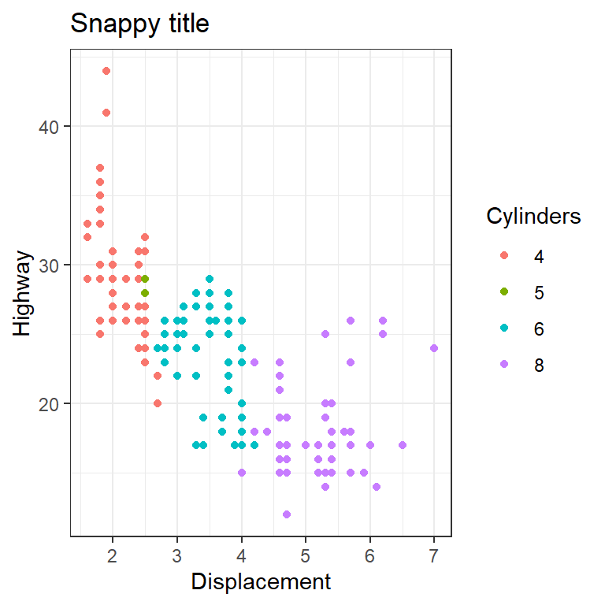

```r
ggplot(mpg, aes(displ, hwy, color = factor(cyl))) +
  geom_point() +
  labs(x = "Displacement", y = "Highway", title = "Snappy title", color = "Cylinders") +
  theme_bw() # adds a black and white theme
```

Other pre-built themes:

- `theme_bw()`
- `theme_linedraw()`, `theme_light()` and `theme_dark()`
- `theme_minimal()`
- `theme_classic()`
- `theme_void()`

You can judge the differences in these themes below:

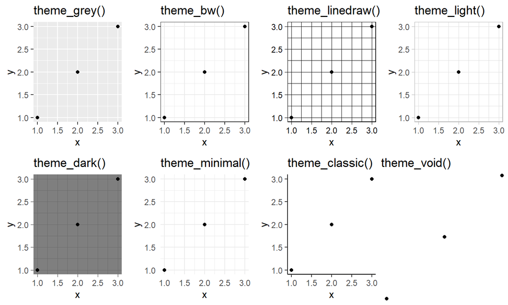

Any theme can be further customized using `theme()`.

**Question 14** Create a ggplot that includes either a color or shape aesthetic, with appropriately labeled axes, legend, and title. Add any of the pre-built themes shown above. Then, using the `theme` function, further modify the plot so that the legend position is on the bottom (Hint: `?theme`)

## Scales

From our discussion in the previous lab, we know that aesthetics responsible for creating a map from the data used to visual aspects of the plot generated. The specific details of how this mapping occurs are contained within the concept of *scales*. Scales, for example, are responsible for determining the length of the x-axis or the specific colors and shapes generated by an aesthetic. Here we are going to limit our discussion to the axes and colors, but the general principles will be true for all of the aesthetics generated by `ggplot2`.

A major concept that will be critical to keep in mind during this section is the distinction between *continuous* and *discrete* values. Continuous values are those that exist on a spectrum without gaps (which *does* include integers), while discrete values are those that take on a limited (and generally small) number of unique values. In the `mpg` dataset that we have been using so far, the highway fuel economy `hwy` would be an example of a continuous variable, while the class of vehicle, `class`, would be an example of a discrete variable.

### Modifying the axes

Whenever an aesthetic is added to a ggplot, an associated scale is created behind the scenes. For example, as both the vehicle displacement and highway fuel economy are continuous variables, scales for both the x and y axes are made continuous. We can see that when we explicitly add these scales to the plot, nothing changes:

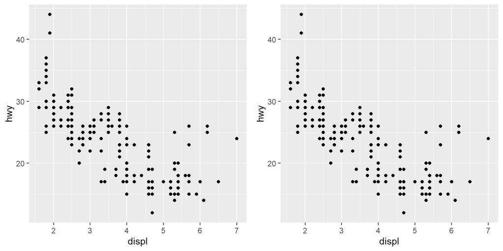

```r
## Scales created behind the scenes
ggplot(mpg, aes(displ, hwy)) +
  geom_point()

## That is the exact same as this
ggplot(mpg, aes(displ, hwy)) +
  geom_point() +
  scale_x_continuous() + # creates continuous x axis
  scale_y_continuous() # creates continuous y axis
```

The same thing occurs when one of the variables is discrete

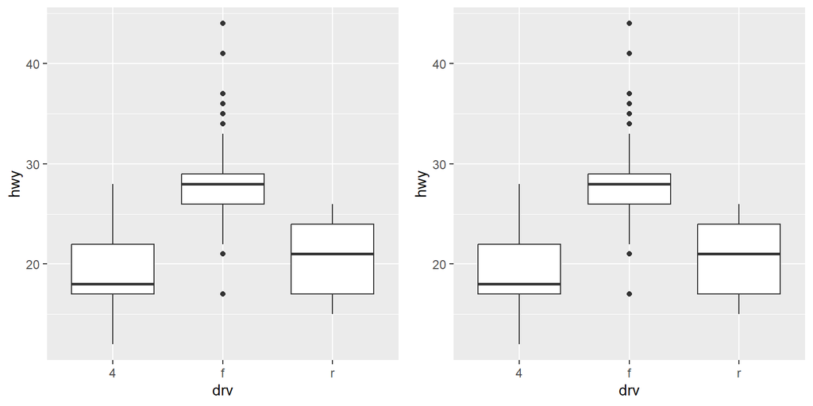

```r
## Scales created behind the scenes
ggplot(mpg, aes(drv, hwy)) +
  geom_boxplot()

## One of these is now discrete
ggplot(mpg, aes(drv, hwy)) +
  geom_boxplot() +
  scale_x_discrete() +
  scale_y_continuous()
```

If we were to try and add a scale that did not match the variable type, we would get an error

```r
## x is discrete but we try to include continuous, resulting in error
ggplot(mpg, aes(drv, hwy)) +
  geom_boxplot() +
  scale_x_continuous() +
  scale_y_continuous()
```

```
## Error: Discrete value supplied to continuous scale
```

Again, because these scale terms are added automatically behind the scenes, we never have to worry about including them specifically unless we wish to change something about them. For now, we will only concern ourselves with breaks, labels, and transformations.

**Question 15** Using the code block below, explicitly add the scales for the x and y axes that would otherwise show up by default

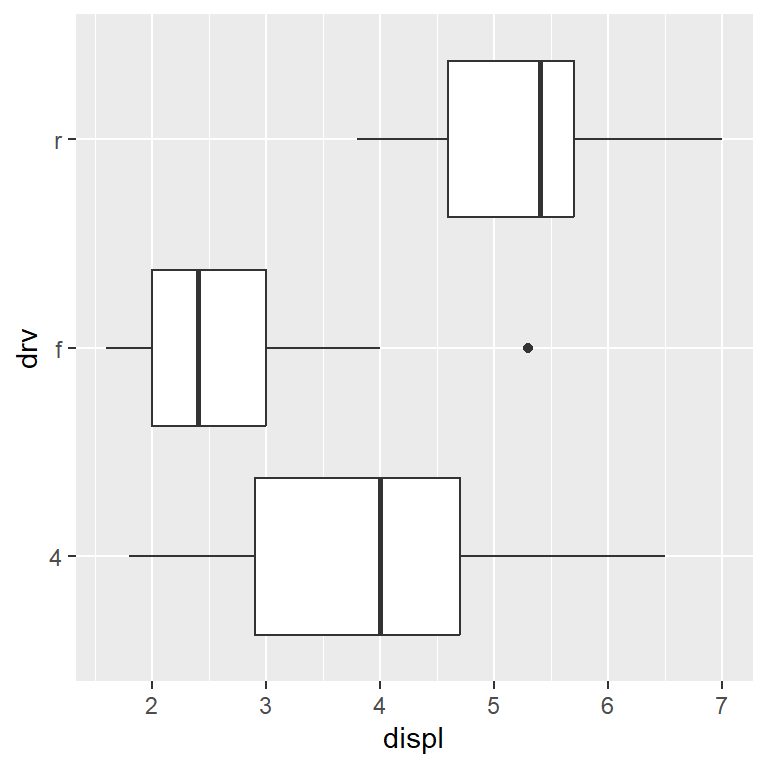

```r
ggplot(mpg, aes(displ, drv)) +
  geom_boxplot()
```

#### Breaks and labels

Breaks and labels refer to the tick marks on the x and y axes. *Breaks* refer to the actual location on the axes we wish to have marks, while *labels* refer to the labels of the breaks. Each of these takes a vector argument, and if both are provided, they must be the same length:

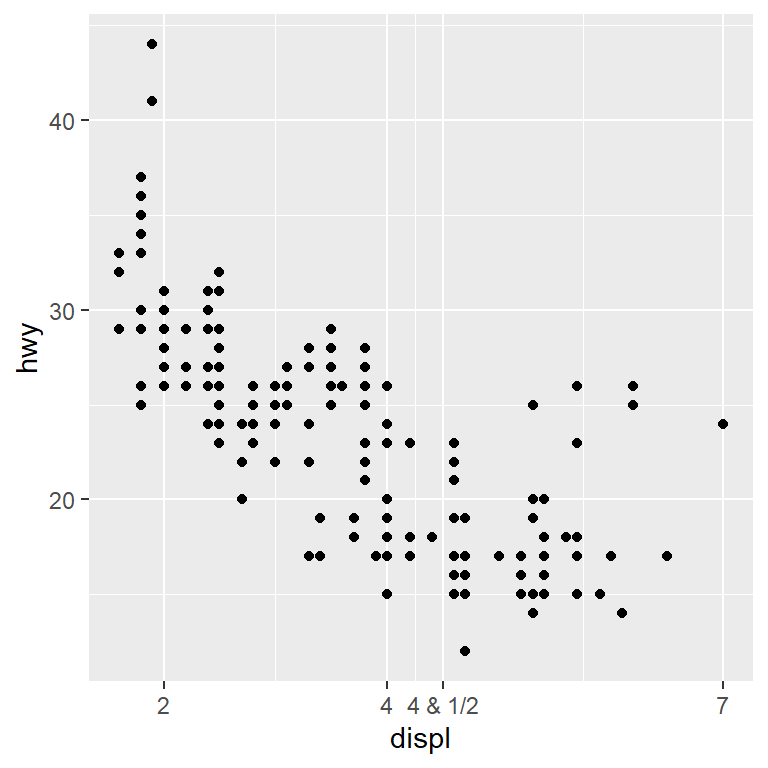

```r
ggplot(mpg, aes(displ, hwy)) +
  geom_point() +
  scale_x_continuous(breaks = c(2, 4, 4.5, 7), labels = c("2", "4", "4 & 1/2", "7"))
```

Because of how the underlying functions work, the breaks and labels falling outside of the range of the data will not render correctly. So, for example, the range of displacement size falls between 1.6 and 7. Any breaks outside of this range will be ignored.

```r
range(mpg$displ)
```

```
## [1] 1.6 7.0
```

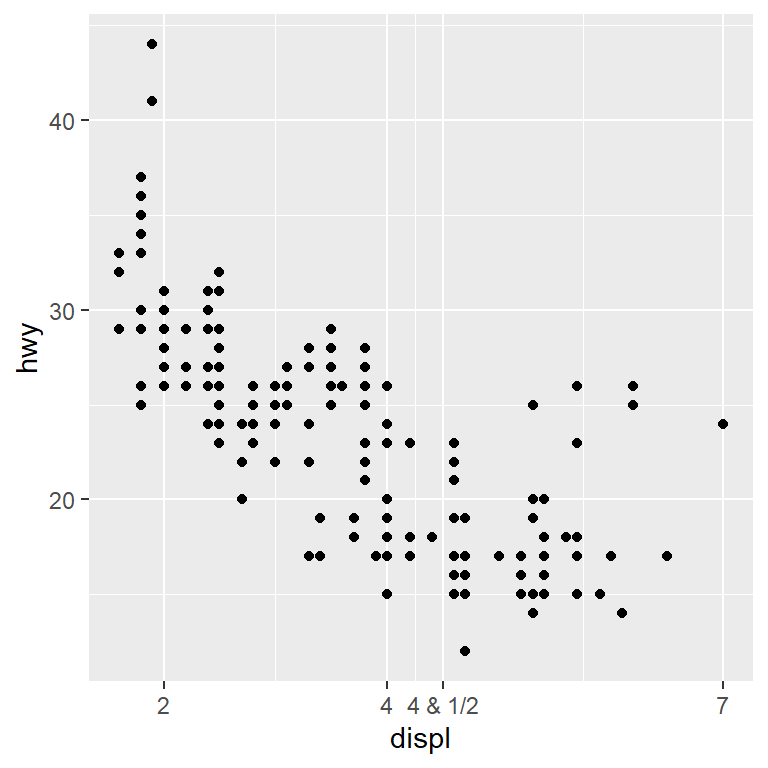

```r
## Because 0 and 8 are not in range, they are ignored
ggplot(mpg, aes(displ, hwy)) +
  geom_point() +
  scale_x_continuous(breaks = c(0, 2, 4, 4.5, 7, 8), labels = c("0", "2", "4", "4 & 1/2", "7", "8"))
```

If we *did* want to include breaks outside of our range, we can do so by adding an argument to `limits` to our scale function that takes new minimum and maximum values. This is often useful if we wish to include zero in our plot, even if zero is not within the range of the data.

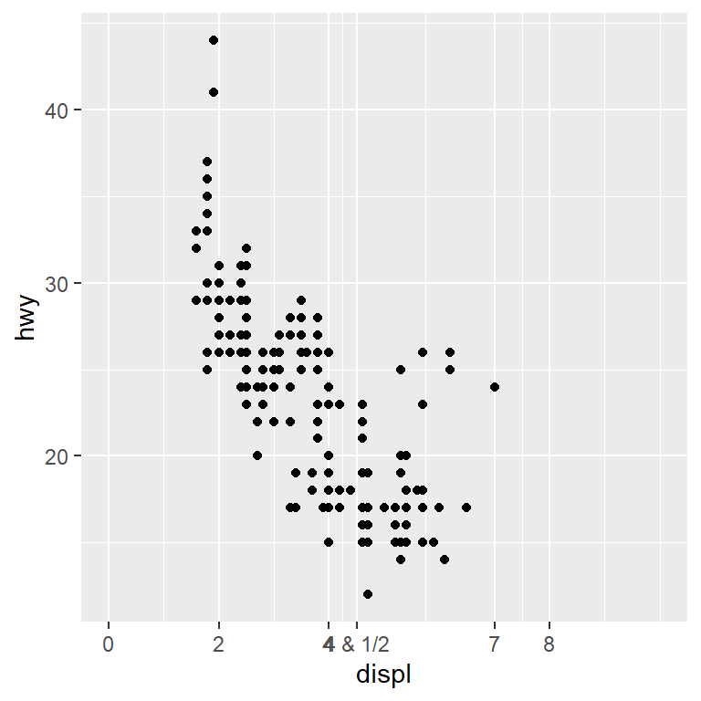

```r
## Increase range of x axis to include 0 and 10
ggplot(mpg, aes(displ, hwy)) +
  geom_point() +
  scale_x_continuous(breaks = c(0, 2, 4, 4.5, 7, 8),
                     labels = c("0", "2", "4", "4 & 1/2", "7", "8"),
                     limits = c(0, 10))
```

When the values are discrete, rather than continuous, the breaks cannot be adjusted as each tick corresponds to a different group. We can, however, change the labels of these groups with a *named vector*. The names of the vector **must** correspond to the names of the group. So, for example, knowing that the `drv` variable has categories “r”, “f”, and “4”, we can make adjustments as such:

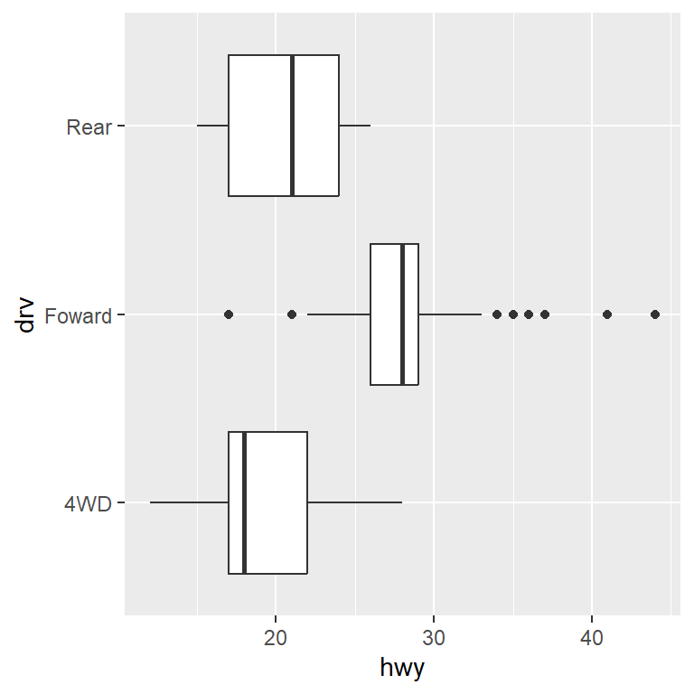

```r
ggplot(mpg, aes(hwy, drv)) +
  geom_boxplot() +
  scale_y_discrete(labels = c(r = "Rear", f = "Foward", `4` = "4WD"))
```

A few things to note from this last plot:

1. Because `drv` is on the y-axis, we need to be sure to use the y scale
2. Ditto for it being discrete
3. Named vectors usually consist of characters and numbers. When special characters are used (such as hypens), or when the name is just a number (as in the case above, where the name was just “4”), we must enclose the name in backtics `` so that R knows what to do with them

**Question 16** Write code to recreate the plot below as closely as possible. In particular, consider themes, breaks, and labels.

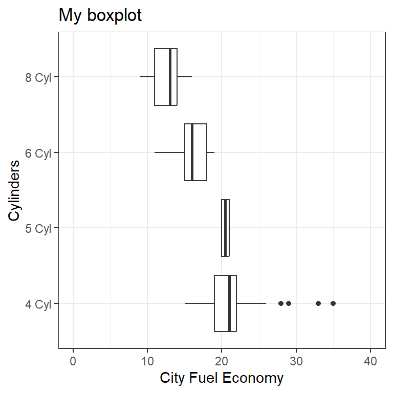

#### Transformations

This last section on our axes scales involves *transformations* and is generally only associated with continuous variables. These are done with the `trans` argument provided in the scale function. For example, if we wish to plot the relationship between displacement and fuel economy in descending order, we could do this by reversing the relevant axis

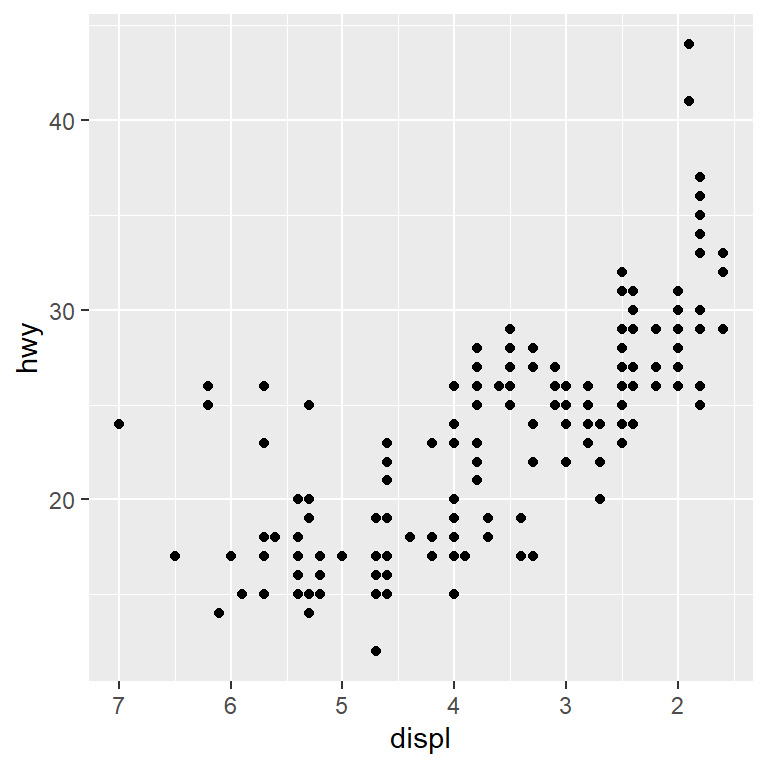

```r
ggplot(mpg, aes(displ, hwy)) +
  geom_point() +
  scale_x_continuous(trans = "reverse")
```

Other transformations help us identify trends that are on disproportionate scales. For example, consider this contrived dataset where each observation grows by a power of 10. This makes it difficult to see any meaningful relationship earlier in the plot. By adjusting the scale for x to be on a $log_{10}$ scale, we are able to better see what is going on

```r
df <- data.frame(x = 1:10, # 1 - 10
                 y = 10^(1:10)) # 10^1 - 10^10
df
```

```
##     x     y
## 1   1 1e+01
## 2   2 1e+02
## 3   3 1e+03
## 4   4 1e+04
## 5   5 1e+05
## 6   6 1e+06
## 7   7 1e+07
## 8   8 1e+08
## 9   9 1e+09
## 10 10 1e+10
```

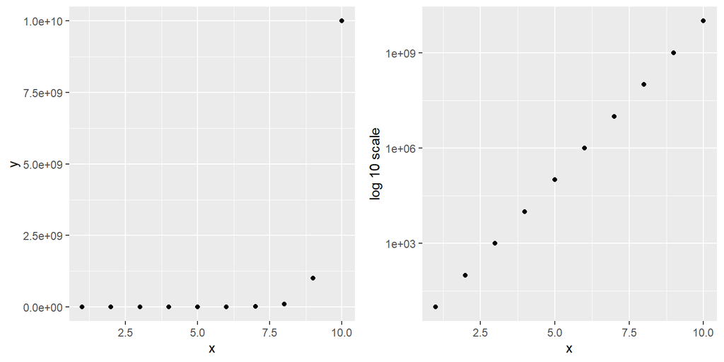

```r
## Very difficult to see this relationship for smaller values
ggplot(df, aes(x, y)) +
  geom_point()

## On a more appropriate scale, we see the relationship is linear
ggplot(df, aes(x, y)) +
  geom_point() + ylab("log 10 scale") +
  scale_y_continuous(trans = "log10")
```

**Question 17** The variable `hwy` in the `mpg` dataset gives us *fuel economy*, which is miles/gallon; however, another common metric is reporting *fuel consumption*, which is a measure of gallons per mile. Use the transformation `"reciprocal"` to create a scatter plot showing the relationship between displacement size and fuel consumption. (Note: for now, don’t worry about the fact that that the labels and breaks on the y-axis have disappeared, this appears to be a mistake in `R`)

## Colors

As mentioned above and explored in the previous section, ggplot manages the relationship between the data and aesthetics through the use of scales. And, we saw, that the scales used for the axes were different depending on whether or not the associated variables were continuous or discrete. As we will now see, the relationship between data and the color aesthetic is no different.

Consider the last lab, for example, in which we plotted the relationship between displacement and highway miles colored by cylinder. When `cyl` was stored as a numeric (or integer) vector, the resulting *color scale* was continuous, taking all values between dark and light blue. However, once we included color as a factor, the color scale became discrete, offering four distinct colors to represent our groups:

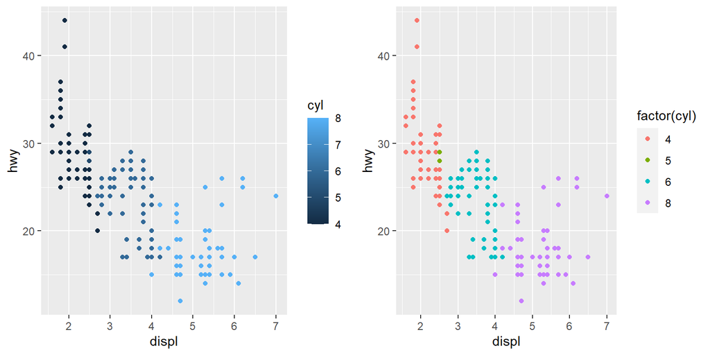

This is an illustration of color being treated as either a *continuous or discrete* scale. And, analogous to the scales we used for our axes, this scales are modified with the functions `scale_color_continuous()` and `scale_color_discrete()`.

### Continuous color scales

There are primarily two types of continuous color scales we will concern ourselves with, and this will depend upon what we are trying to demonstrate. Generally speaking, there are two possible options:

1. *sequential scales* - most useful in distinguishing high values from low values
2. *diverging scales* - used to put equal emphasis on both high and low ends of the data range

Roughly corresponding to these two options are two types of color scales readily available for ggplot: viridis and gradient:

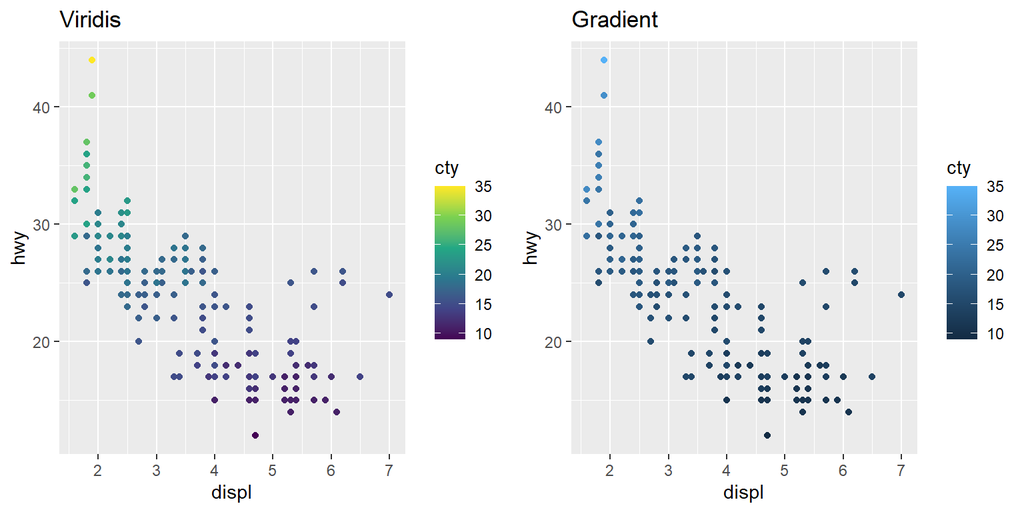

```r
ggplot(mpg, aes(displ, hwy, color = cty)) +
  geom_point() +
  scale_color_continuous(type = "viridis")

ggplot(mpg, aes(displ, hwy, color = cty)) +
  geom_point() +
  scale_color_continuous(type = "gradient")
```

The viridis scales constitute a set of different color maps that are designed with a few thoughts in mind:

1. Colorful with a wide palette, making differences easy to see
2. Perceptually uniform, so that values close together have similar colors
3. Robust to colorblindness, meaning they also do well when printed in black and white

You can read more about viridis scales [here.](https://cran.r-project.org/web/packages/viridis/vignettes/intro-to-viridis.html)

A range of different viridis scales are provided in ggplot, though their description is not particularly well documented. You can select different scales by passing an additional argument `option` with options available for “A”-“H”. Here are a few for illustration:

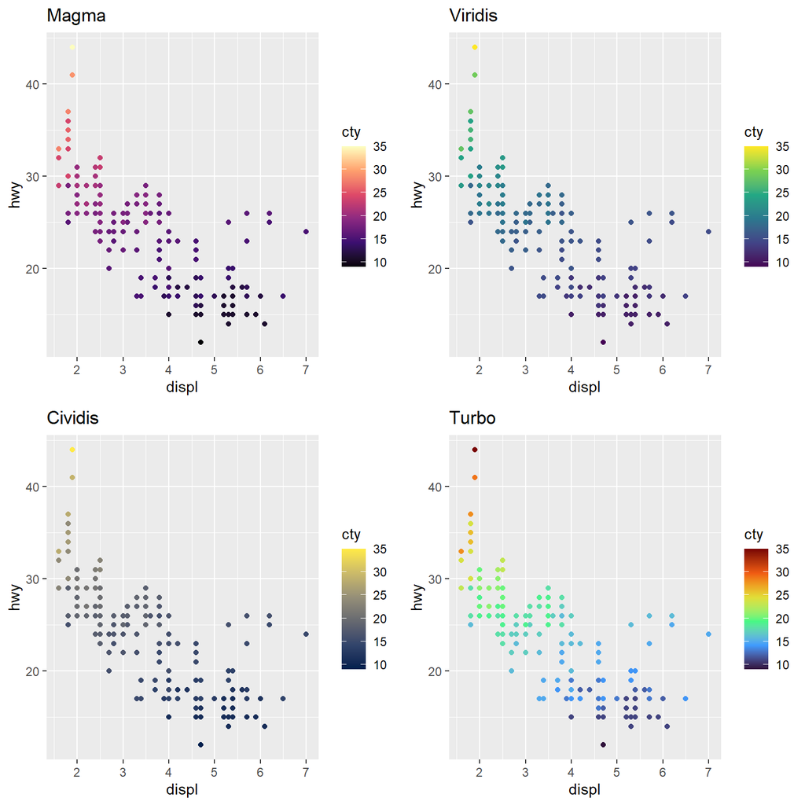

```r
ggplot(mpg, aes(displ, hwy, color = cty)) +
  geom_point() +
  scale_color_continuous(type = "viridis", option = "A") + ggtitle("Magma")

ggplot(mpg, aes(displ, hwy, color = cty)) +
  geom_point() +
  scale_color_continuous(type = "viridis", option = "D") + ggtitle("Viridis")

ggplot(mpg, aes(displ, hwy, color = cty)) +
  geom_point() +
  scale_color_continuous(type = "viridis", option = "E") + ggtitle("Cividis")

ggplot(mpg, aes(displ, hwy, color = cty)) +
  geom_point() +
  scale_color_continuous(type = "viridis", option = "H") + ggtitle("Turbo")
```

The gradient color type, on the other hand, gives you a bit more control. Here, you can specify a `high` and `low` value, indicating the range of colors on which you wish to gradient. Choosing colors that are on the opposite ends of a color wheel will give you the best contrast.

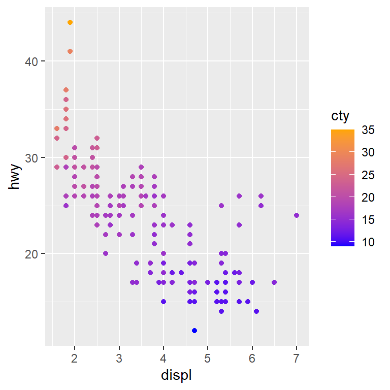

```r
ggplot(mpg, aes(displ, hwy, color = cty)) +
  geom_point() +
  scale_color_continuous(type = "gradient", high = "orange", low = "blue")
```

A list of colors provided in R are available [here](http://www.stat.columbia.edu/~tzheng/files/Rcolor.pdf)

**Question 18** For this question, we are going to use another dataset built into R, the `USArrests` (see `?USArrets`). Create a scatter plot using this data with the urban population on the x-axis and the number of assaults per 100,000 residents on the y-axis. Then, choose two sensible colors and add a color gradient corresponding to the murder rate. Looking at this plot, does it seem that high rates of murder are more likely to correspond with larger urban population or with states with high rates of assault?

### Discrete color scales

While there is an associated `scale_color_discrete()` function for use with discrete variables, we will instead use a similar function, `scale_color_brewer()`, which comes with a full suite of pre-built palettes for use with discrete variables. These can be found in the documentation for `?scale_color_brewer()`. The great thing about this is that with minimal effort, we can feel confident that our colors are going to look good

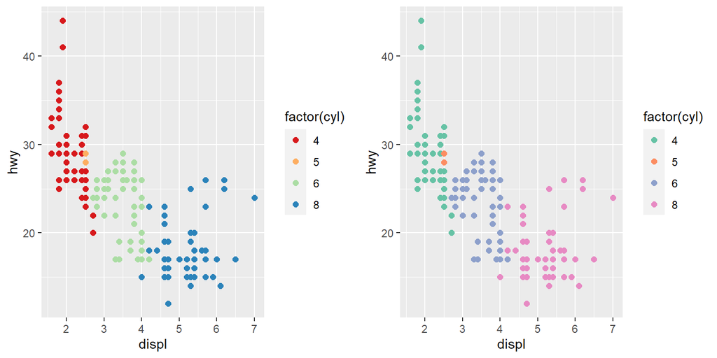

```r
ggplot(mpg, aes(displ, hwy, color = factor(cyl))) +
  geom_point() + scale_color_brewer(palette = "Spectral")

ggplot(mpg, aes(displ, hwy, color = factor(cyl))) +
  geom_point() + scale_color_brewer(palette = "Set2")
```

Although I don’t recommend it, you can also specify your own colors for different values passing a named vector to `scale_color_manual`

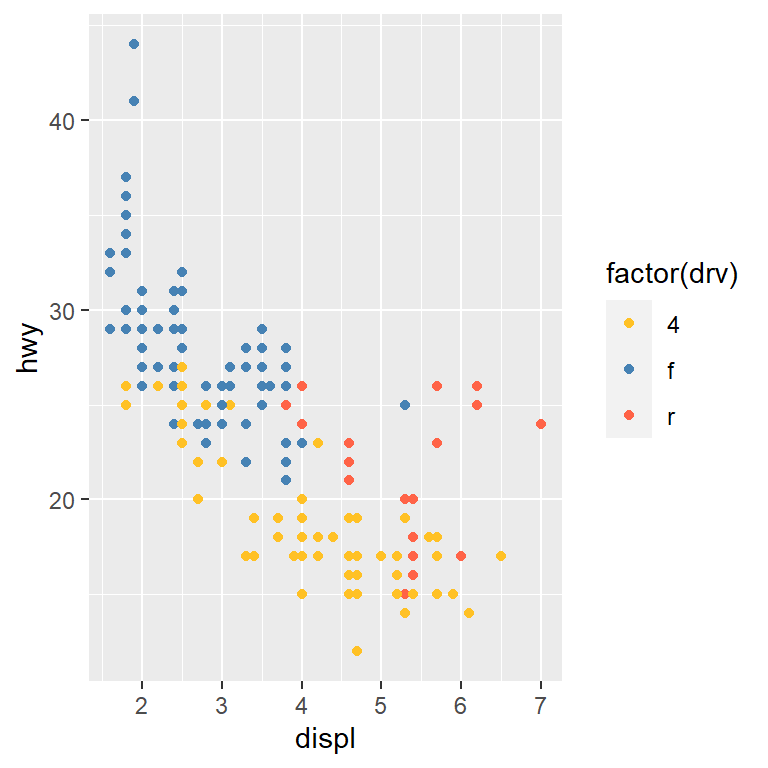

```r
ggplot(mpg, aes(displ, hwy, color = factor(drv))) +
  geom_point() +
  scale_color_manual(values = c(f = "steelblue", r = "tomato", `4` = "goldenrod1"))
```

**Question 19** This time we are going to use the builtin R dataset `ChickWeight` (`?ChickWeight`). Put `Time` on the x-axis and `weight` on the y-axis, and specify the color aesthetic with `Diet`. In addition to adding scatter points, add a layer with `geom_smooth`. Finally, use a different color palette than the default, either a pre-built one with the brewer function or by selecting the colors manually. By the end of the study, which diet seemed to result in chicks with the greatest average weight?

## Barplots and fill

We conclude our lab on ggplot with a discussion of a new layer and associated geom – bar plots and fill. Let’s begin by subsetting our data to only include those vehicles whose manufacturer is Chevrolet, Dodge, or Ford. We can check inclusion with the `%in%` operator which we will investigate in more detail later. We then create this bar plot with a call to `geom_bar()`.

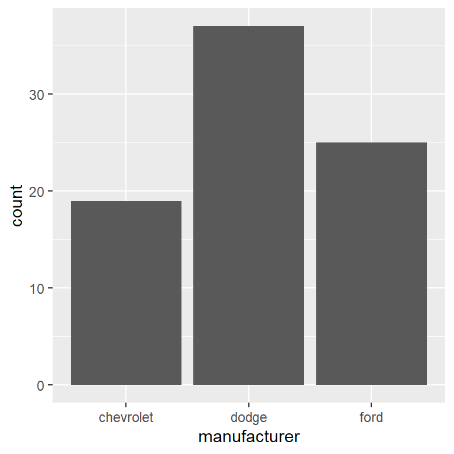

```r
mpg2 <- subset(mpg, manufacturer %in% c("chevrolet", "dodge", "ford"))

ggplot(mpg2, aes(manufacturer)) +
  geom_bar()
```

Along the x-axis, we see the three manufacturers included in our dataset, and along with y-axis, the frequency with which each of them appears in our dataset. Suppose we wish to further identify how many of each type of drive train is included from each manufacturer. We can use the color aesthetic, but it is likely not what we are anticipating. Instead, we need to introduce a new aesthetic, `fill`

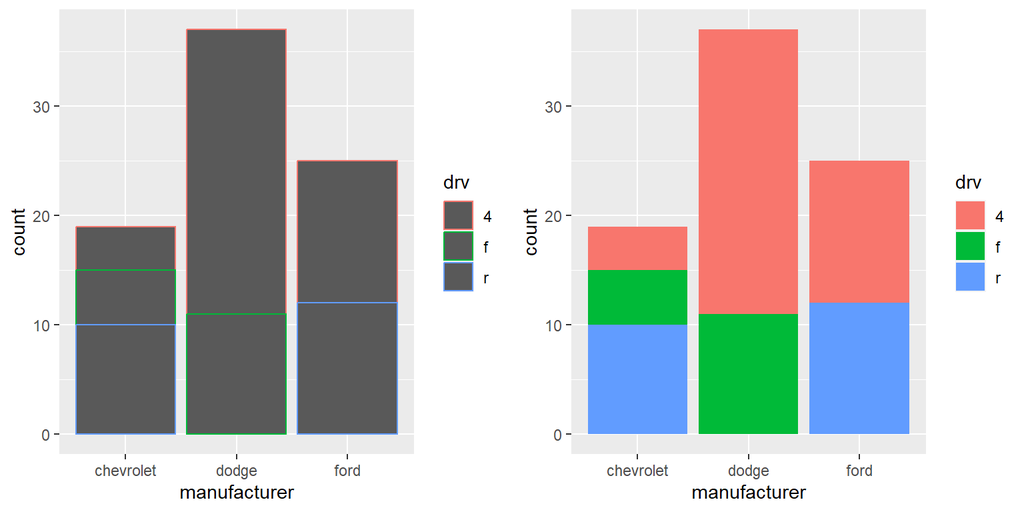

```r
ggplot(mpg2, aes(manufacturer, color = drv)) +
  geom_bar()

ggplot(mpg2, aes(manufacturer, fill = drv)) +
  geom_bar()
```

Note that `fill` is also the aesthetic we would use to fill in our box plots if we chose to do so.

By default, `geom_bar()` provides a count of the total number of each observations within each group. Once we have specified a (discrete) grouping variable, we have a few additional options. The default here, again, is to simply leave the bars stacked with the total frequency provided on the y-axis. We can modify this with the argument `position`. Up first, we consider setting `position = "fill"`, which forces the height of each bar to sum up to 1

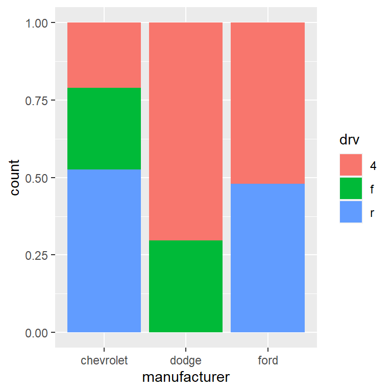

```r
ggplot(mpg2, aes(manufacturer, fill = drv)) +
  geom_bar(position = "fill")
```

Although this gives us no information on the differences between manufacturers, it tells us a great deal about the composition of drive trains *within* each manufacturer. For example, we see that just a little over 50% of the Chevrolets in our dataset have rear wheel drive, while read wheel drive makes up just under 50% of Fords, and none of the Dodges.

Another useful position for our bar plots is `"dodge"`, which splits the different groups and plots their frequency side-by-side.

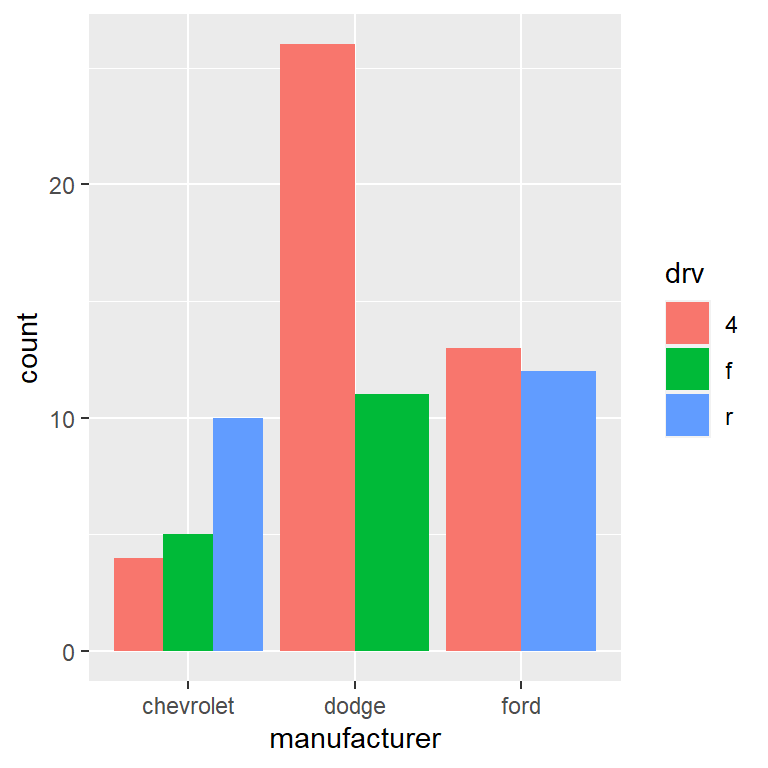

```r
ggplot(mpg2, aes(manufacturer, fill = drv)) +
  geom_bar(position = "dodge")
```

What is interesting about this (and perhaps a little off-putting) is that this preserves the total width for each manufacturer. This results in the individual drive train bars for Chevrolet all being smaller than the drive train bars for Dodge and Ford. If we wish instead for the grouping variables to be of equal width, we need to use an *element function* similar to what we did when modifying text. In this case, the element function is `position_dodge(preserve = "single")` or `position_dodge2(preserve = "single")`, which adds a tiny bit of space between the bars.

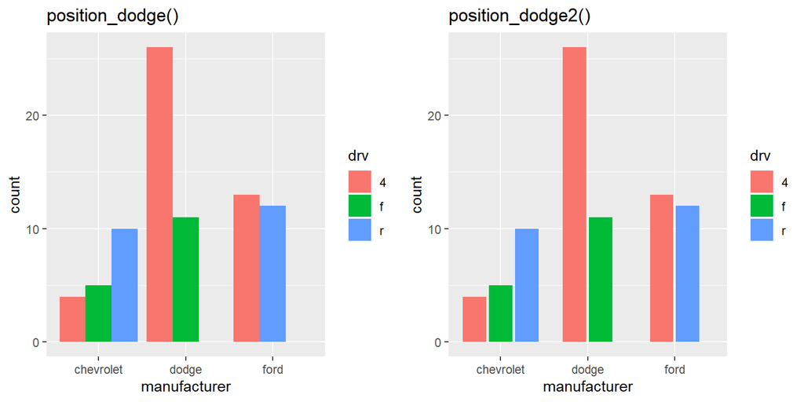

```r
ggplot(mpg2, aes(manufacturer, fill = drv)) +
  geom_bar(position = position_dodge(preserve = "single"))

ggplot(mpg2, aes(manufacturer, fill = drv)) +
  geom_bar(position = position_dodge2(preserve = "single"))
```

**Question 20** For this question, we are going to use the built-in dataset in R, `ToothGrowth` (`?ToothGrowth`) which measures the length of odontoblasts (cells responsible for tooth growth) in 60 guinea pigs in response to the administration of supplemental vitamin C. Three different doses of the vitamin were given via two different delivery methods, either orange juice or ascorbic acid. Begin by creating a box plot with the length of odontoblasts on the x-axis and the dose on the y-axis. Use the `fill` aesthetic to indicate supplement type, and use `scale_fill_brewer()` to select a different palette for the colors. What can we learn from this plot? Is a higher dose of vitamin C associated with increased tooth growth? Did either of the supplements appear any better than the other?

## Practice problem

(Taken from Professor Miller)

**Question 21** The code below will load a data set containing 970 Hollywood films released between 2007 and 2011, then reduce these data to only include variables that could be known prior to a film’s opening weekend. The data are then simplified further to only include the four largest studios (Warner Bros, Fox, Paramount, and Universal) in the three most common genres (action, comedy, drama). You will use the resulting data (ie: `movies_subset`) for this question.

```r
movies = read.csv("https://remiller1450.github.io/data/HollywoodMovies.csv")
movies_subset = subset(movies, LeadStudio %in% c("Warner Bros", "Fox", "Paramount", "Universal") &
                               Genre %in% c("Action", "Comedy", "Drama"),
                       select = c("Movie", "LeadStudio", "Story", "Genre","Budget",
                                  "TheatersOpenWeek","Year","OpeningWeekend"))
```

Your goal in this question is to create a graphic that effectively differentiates movies with high revenue on opening weekend from those with low revenue on opening weekend (the variable `OpeningWeekend` records this revenue in millions of US dollars). To practice the topics introduced in this lab, your graphic should include *at least* 3 of the following 5 components:

1. Scale modifications (color, axes, shapes, fill, etc.,)
2. Stat summaries
3. Labels or annotations
4. Theme changes
5. Faceting

Finally, using the graph you created, write 2-3 sentences explaining the trends you found (ie: what attributes seem to predict a film having low/high opening weekend revenue).